# lm_fit for covid infection and temperature

# Linear Model fit

statistic mode
$$\pmb{Y= \beta_0+\beta_1T+\epsilon \quad where \quad \epsilon \sim N(0,\sigma^2)}$$
$$Y \sim N(0,\sigma^2)$$
$$\pmb{E}(y_i)=E(\beta_0+\beta_1x_i+\epsilon_i)=\beta_0+\beta_1x_i+E(\epsilon_i)=\beta_0+\beta_1x_i$$

$$Var(y_i)=Var(\beta_0+\beta_1T+\epsilon_i)=Var(\epsilon_i)=\sigma^2$$

```r
LUX_fit <- LUX %>%
  filter(date<end_date & date>start_date) %>%
  filter(weekly_temp>0) %>%
  lm(logC ~ weekly_temp, data = .)

summary(LUX_fit)
```

```
##
## Call:
## lm(formula = logC ~ weekly_temp, data = .)
##
## Residuals:
##      Min       1Q   Median       3Q      Max
## -1.39559 -0.34206 -0.05909  0.30665  1.60155
##
## Coefficients:
##             Estimate Std. Error t value Pr(>|t|)
## (Intercept)  7.96095    0.13607  58.506  < 2e-16 ***
## weekly_temp -0.10475    0.01054  -9.934 5.25e-15 ***
## ---
## Signif. codes:  0 '***' 0.001 '**' 0.01 '*' 0.05 '.' 0.1 ' ' 1
##
## Residual standard error: 0.5612 on 70 degrees of freedom
## Multiple R-squared:  0.585,  Adjusted R-squared:  0.5791
## F-statistic: 98.69 on 1 and 70 DF,  p-value: 5.251e-15
```

```r
confint(LUX_fit)
```

```
##                  2.5 %      97.5 %
## (Intercept)  7.6895644  8.23232947
## weekly_temp -0.1257824 -0.08372189
```

```r
LUX_C <- LUX %>%
  filter(date<end_date & date>start_date)
cor(LUX_C$weekly_temp, LUX_C$logC)
```

```
## [1] -0.7140437
```

```r
cov(LUX_C$weekly_temp, LUX_C$logC)
```

```
## [1] -4.076929
```

```r
BLG_fit <- BLG %>%
  filter(date<end_date & date>start_date) %>%
  filter(weekly_temp>0) %>%
  lm(logC ~ weekly_temp, data = .)

summary(BLG_fit)
```

```
##
## Call:
## lm(formula = logC ~ weekly_temp, data = .)
##
## Residuals:
##      Min       1Q   Median       3Q      Max
## -2.59607 -0.53391 -0.02595  0.43295  2.07847
##
## Coefficients:
##             Estimate Std. Error t value Pr(>|t|)
## (Intercept) 10.90425    0.23210  46.981  < 2e-16 ***
## weekly_temp -0.10726    0.01739  -6.167 3.79e-08 ***
## ---
## Signif. codes:  0 '***' 0.001 '**' 0.01 '*' 0.05 '.' 0.1 ' ' 1
##
## Residual standard error: 0.8436 on 71 degrees of freedom
## Multiple R-squared:  0.3488, Adjusted R-squared:  0.3397
## F-statistic: 38.04 on 1 and 71 DF,  p-value: 3.79e-08
```

```r
confint(BLG_fit)
```

```
##                  2.5 %      97.5 %
## (Intercept) 10.4414526 11.36704396
## weekly_temp -0.1419367 -0.07258258
```

```r
BLG_C <- BLG %>%
  filter(date<end_date & date>start_date)
cor(BLG_C$weekly_temp, BLG_C$logC)
```

```
## [1] -0.5539916
```

```r
cov(BLG_C$weekly_temp, BLG_C$logC)
```

```
## [1] -3.425507
```

## Fitting model for the data in Luxembourg Ŷ = 7.96 - 0.105∙T

$$\hat{Y}=7.96 - 0.105∙T$$
## Fitting model for the data in Blegium Ŷ = Ŷ = 10.9 - 0.107∙T

$$\hat{Y}=Ŷ = 10.9 - 0.107∙T$$
## estimation analysis Hypothesis:
$$H_0：\beta_1 =0 ；H1:\beta _1 \neq0$$

##Test based on the hyperthesis

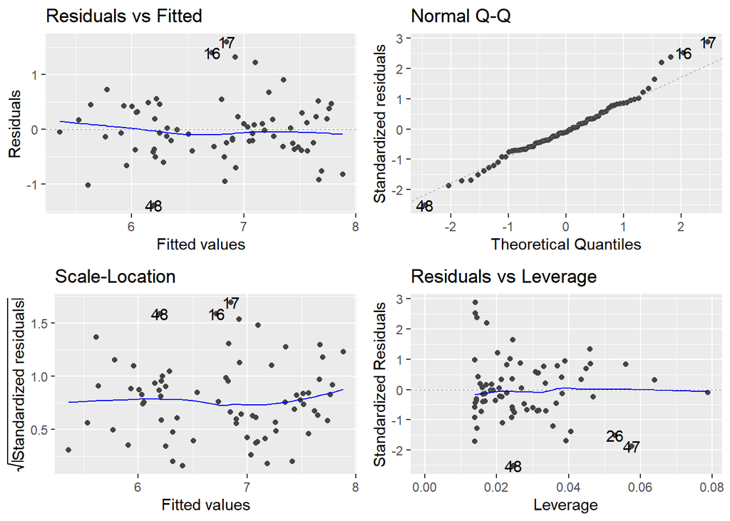

```r
autoplot(LUX_fit)
```

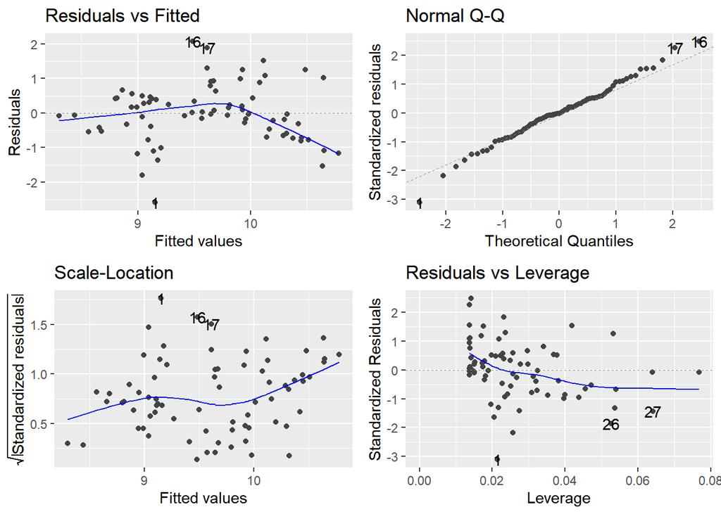

```r
autoplot(BLG_fit)
```

## calculate T and P values. As observed from the above results, calculated P value is less than alpha. This gave us enough evidence with 95% confidence we say that we reject null hypothesis. In other words, with %95 confidence beta value is not zero. So we reject $ H_0：_1 =0 $.

## Fitting model figure plot

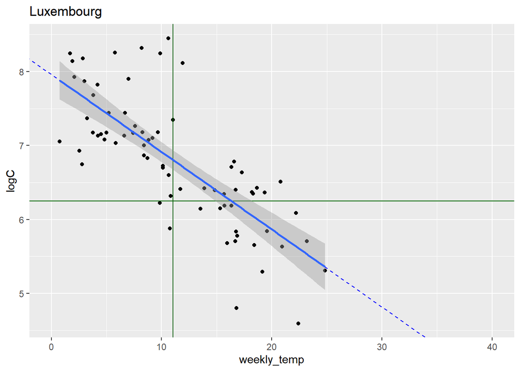

```r
LUX %>%
  filter(date<end_date & date>start_date) %>%
  filter(weekly_temp>0 ,new_cases>0) %>%
  ggplot(aes(weekly_temp, logC))+
  geom_point()+
    geom_abline(slope = coef(LUX_fit)[2], intercept = coef(LUX_fit)[1],linetype=2, color= "blue")+
    geom_hline(yintercept = mean(LUX$logC), color = "darkgreen") +
    geom_vline(xintercept = mean(LUX$weekly_temp), color = "darkgreen")+
  stat_smooth(method = lm,)+
  xlim(0, 40)+
  ggtitle("Luxembourg")
```

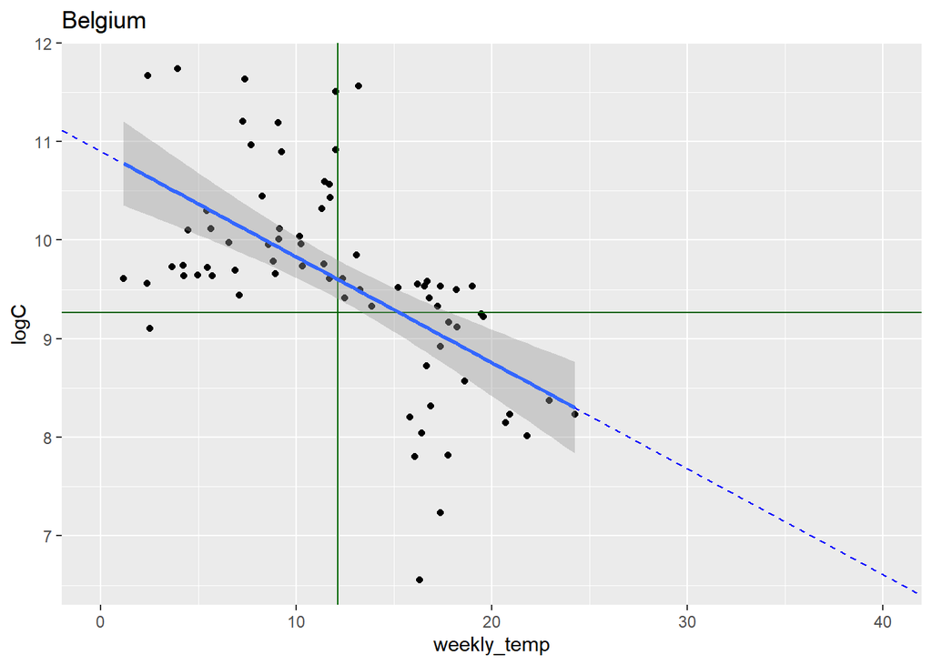

```r
BLG %>%
  filter(date<end_date & date>start_date) %>%
  filter(weekly_temp>0 ,new_cases>0) %>%
  ggplot(aes(weekly_temp, logC))+
  geom_point()+
    geom_abline(slope = coef(BLG_fit)[2], intercept = coef(BLG_fit)[1],linetype=2, color= "blue")+
    geom_hline(yintercept = mean(BLG$logC ), color = "darkgreen") +
    geom_vline(xintercept = mean(BLG$weekly_temp), color = "darkgreen")+
  stat_smooth(method = lm,)+
  xlim(0, 40)+
  ggtitle("Belgium")
```

## Residual analysis

Hypothesis:
$$H_0: Residual\sim N(0,\sigma^2) ；H1:Residual \quad !\sim N(0,\sigma^2)$$

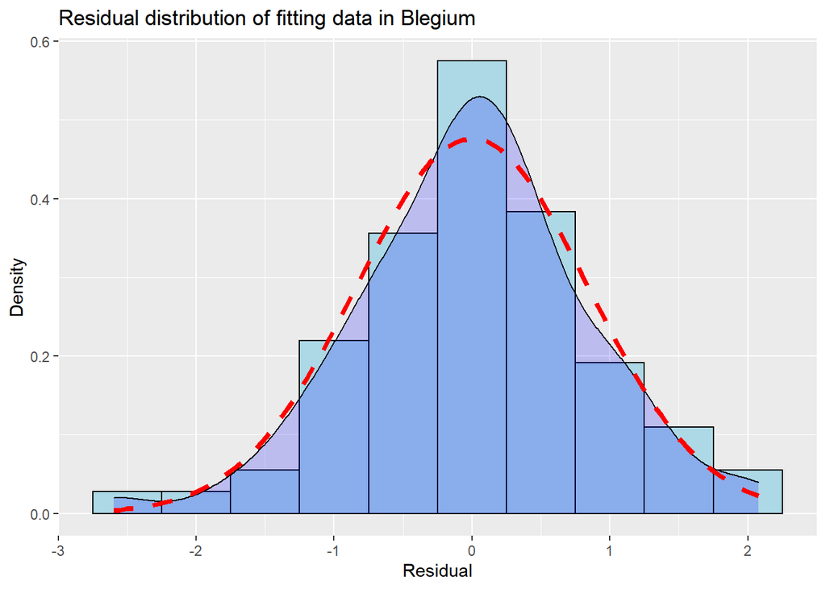

```r
library(broom)
BLG_temp_case <- BLG %>%
  filter(date<end_date & date>start_date) %>%
  filter(weekly_temp>0 ,new_cases>0) %>%
  mutate(expected = augment(BLG_fit)$.fitted) %>%
  mutate(residual = log(new_cases)-expected)


ggplot(BLG_temp_case, aes(x=residual)) +
    geom_histogram(aes(y=..density..),
                   binwidth=.5,
                   colour="black", fill="light blue") +
    geom_density(alpha=.2, fill="blue")+
    stat_function(
    fun = dnorm,
    args = list(mean = mean(BLG_temp_case$residual), sd = sd(BLG_temp_case$residual)),
    linetype=2,
    size= 1.5,
    colour="red" )+
  labs(
    x = "Residual", y = "Density",
    title = "Residual distribution of fitting data in Blegium"
  )
```

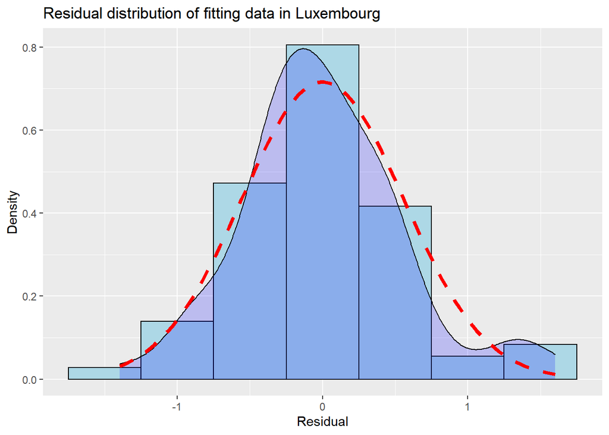

```r
library(broom)
LUX_temp_case <- LUX %>%
  filter(date<end_date & date>start_date) %>%
  filter(weekly_temp>0 ,new_cases>0) %>%
  mutate(expected = augment(LUX_fit)$.fitted) %>%
  mutate(residual = log(new_cases)-expected)

ggplot(LUX_temp_case, aes(x=residual)) +
    geom_histogram(aes(y=..density..),
                   binwidth=.5,
                   colour="black", fill="light blue") +
    geom_density(alpha=.2, fill="blue") +
    stat_function(
    fun = dnorm,
    args = list(mean = mean(LUX_temp_case$residual), sd = sd(LUX_temp_case$residual)),
    linetype=2,
    size= 1.5,
    colour="red")+
    labs(
    x = "Residual", y = "Density",
    title = "Residual distribution of fitting data in Luxembourg")
```

# Shapiro Test

```r
y.res<-residuals(LUX_fit)
head(y.res)
```

```
##           1           2           3           4           5           6
## -0.36787004  0.30314991  0.42828670  0.44904982  0.17158855 -0.05183344
```

```r
shapiro.test(y.res)
```

```
##
##  Shapiro-Wilk normality test
##
## data:  y.res
## W = 0.97531, p-value = 0.1682
```

```r
y2.res<-residuals(BLG_fit)
head(y2.res)
```

```
##           1           2           3           4           5           6
## -2.59607313 -1.80600729 -1.17845483 -0.42601658 -0.06624362 -0.07265795
```

```r
shapiro.test(y2.res)
```

```
##
##  Shapiro-Wilk normality test
##
## data:  y2.res
## W = 0.99044, p-value = 0.8603
```

# The selected significance level alpha = 0.05 which is less than p value for both cases. This means, p value area coves the alpha completely so we don’t have enough evidence to reject null hypothesis. Hence the residual population is Normal.

#Compare the coeffiencts in Luxembourg ($\hat{\beta}_1$) and Belgium($\hat{\beta}_1$)

```r
BLG_sum <- BLG_temp_case %>%
  filter(date<end_date & date>start_date) %>%
  filter(weekly_temp>0 ,new_cases>0) %>%
  mutate(dif_x = weekly_temp - mean(weekly_temp)) %>%
  mutate(difx2=dif_x^2)%>%
  summarise(Sxx = sum(difx2),
            m2 = mean(residual),
            s2 = sd(residual),
            V_B = sqrt(abs(s2/Sxx)))
head(BLG_sum  )
```

```
## # A tibble: 1 x 4
##     Sxx        m2    s2    V_B
##   <dbl>     <dbl> <dbl>  <dbl>
## 1 2353. -1.22e-15 0.838 0.0189
```

```r
LUX_sum <- LUX_temp_case %>%
  filter(date<end_date & date>start_date) %>%
  filter(weekly_temp>0 ,new_cases>0) %>%
  mutate(dif_x = weekly_temp - mean(weekly_temp)) %>%
  mutate(difx2=dif_x^2)%>%
  summarise(Sxx = sum(difx2),
            m2 = mean(residual),
            s2 = sd(residual),
            V_B = sqrt(abs(s2/Sxx)))
head(LUX_sum  )
```

```
##       Sxx            m2        s2        V_B
## 1 2833.09 -8.264749e-16 0.5572808 0.01402513
```

## Visulasition of the coeffiencts in Luxembourg ($\hat{\beta}_1$) and Belgium($\hat{\beta}_1$)

```r
set.seed(0109)
dat <-   tibble(
    x = seq(-0.18,-0.035,length.out = 1000),
    y1 = dnorm(x, -0.107, BLG_sum$V_B),
    y2 = dnorm(x, -0.105, LUX_sum$V_B))
head(dat)
```

```
## # A tibble: 6 x 3
##        x     y1        y2
##    <dbl>  <dbl>     <dbl>
## 1 -0.18  0.0119 0.0000176
## 2 -0.180 0.0122 0.0000186
## 3 -0.180 0.0126 0.0000196
## 4 -0.180 0.0130 0.0000207
## 5 -0.179 0.0134 0.0000219
## 6 -0.179 0.0138 0.0000231
```

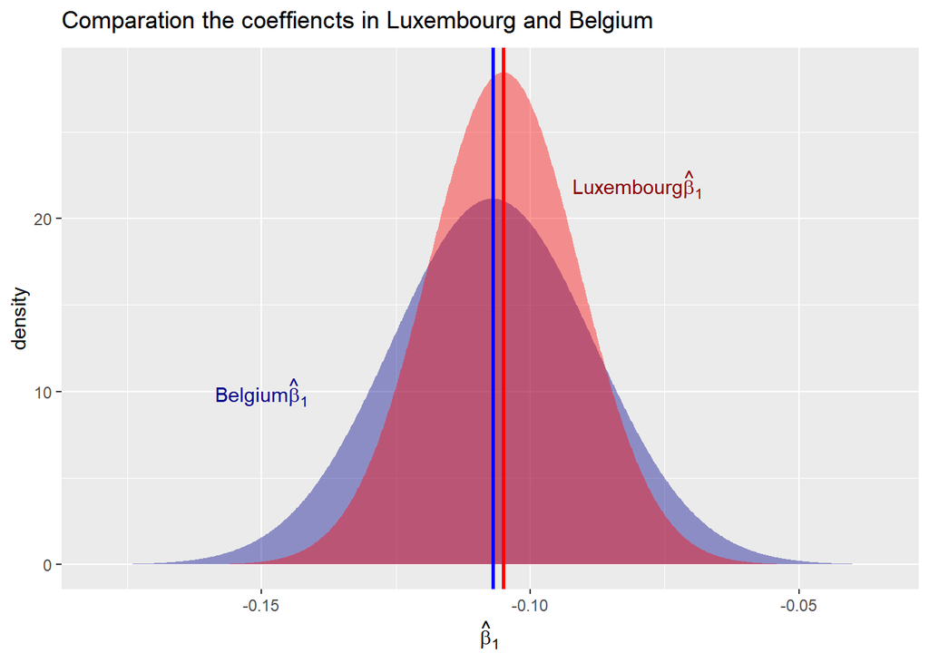

```r
  ggplot(dat) +
  geom_area(aes(x,y1),fill = "darkblue", alpha = 0.4)+
  geom_area(aes(x,y2),fill = "red", alpha = 0.4)+
  geom_vline(xintercept = -0.107, color = "blue",lwd=1) +
  geom_vline(xintercept = -0.105, color = "red",lwd=1)+
  labs(title = expression("Comparation the coeffiencts in Luxembourg and Belgium"),
         x = expression(hat(beta)[1]),
         y = "density",
      col = expression(paste('Values of ', mu)))+
    annotate("text", x=-0.15, y=10, colour="darkblue", label= expression(paste("Belgium", hat(beta)[1]))) +
    annotate("text", x=-0.08, y=22,colour="darkred", label= expression(paste("Luxembourg", hat(beta)[1])))
```

## Conclusion # The results clearly support the statistically significant relationship of negative correlation between the average environmental temperature and exponential growth rates of the infected cases.

##Prediction

```r
new.dat <- data.frame(weekly_temp=35)
predict(BLG_fit, newdata = new.dat, interval = 'confidence')
```

```
##        fit      lwr      upr
## 1 7.150161 6.331278 7.969044
```

```r
new.dat <- data.frame(weekly_temp=35)
predict(LUX_fit, newdata = new.dat, interval = 'confidence')
```

```
##        fit      lwr      upr
## 1 4.294622 3.778579 4.810666
```

## Reference

[1] Livadiotis G. Statistical analysis of the impact of environmental temperature on the exponential growth rate of cases infected by COVID-19[J]. PLoS one, 2020, 15(5): e0233875. [2] Relman D. A. Rapid Expert Consultation on SARS-CoV-2 Survival in Relation to Temperature and Humidity and Potential for Seasonality for the COVID-19 Pandemic. The National Academies Press. 2020; https://doi.org/10.17226/25771